# Fika Factory data analysis

Investigation of the cookie dissolving time

Sofia Drobysheva

12/12/2021

## Background info

This report includes analysis of the data that comes from an **imaginary** Fika Factory. The factory produces several types of cookies: chocolate, oat and cherry. The chocolate cookies are the main focus of the company.

Cookies are produced in batches. Before the the batch can be sold it must pass the quality control test. The test is the following: several cookies are selected and their average dissolving time in a glass of milk is measured. The idea behind it is to make sure that cookies do not dissolve too quickly. If the average dissolving time is more than 4 seconds then the batch is declared as **GOOD**. If the dissolving time is on average less than 4 seconds, then the batch is a **FAIL** and cannot be sold.

## Purpose of the analysis

Recently cookies were seen to dissolve too quickly. Thus, a data analyst was hired to investigate the data and understand **what** may cause a shift in the dissolving time of the cookies.

We will test two hypothesis:

1. Cookie dissolving time in milk is not affected by whom the cookies are made.
2. Cookie dissolving time in milk is not affected by the local temperature.

## The dataset

Before we start diving deeper into the data, lets look at what we know:

1. Factory employs two bakers: Tom Hoffman and Bob Fredrikson.
2. Several dissolving tests are made. Dissolving in milk, in water, juice, coffee and tea. The most important parameter for the company is: dissolving in milk.
3. The factory sells three types of cookies: chocolate (majority), oat and dried-cherry.
4. A TEST chocolate cookie batch was requested for this analysis. This was done to have a thick-dough reference batch.

The main Fika Factory dataset is presented in the table below:

The main dataset

| batch_id | cookie_type | test_date | cookie_made_by | taste_quality | stats | water | juice | coffee | tea | milk | comment |
| --- | --- | --- | --- | --- | --- | --- | --- | --- | --- | --- | --- |
| 10 | Choco-cookie | 28-Apr-20 | tom_h | 8.2 | Mean | 3.8 | 10.3 | 1.2 | 0.8 | 6.5 | NA |
| 10 | Choco-cookie | 28-Apr-20 | tom_h | 8.2 | st_dev | 0.9 | 1.4 | 0.5 | 0.1 | 1.6 | NA |
| 69 | Choco-cookie | 10-Jun-20 | tom_h | 7.3 | Mean | 5.4 | 13.0 | 1.6 | 1.0 | 7.8 | NA |
| 69 | Choco-cookie | 10-Jun-20 | tom_h | 7.3 | st_dev | 0.8 | 2.0 | 1.7 | 0.6 | 2.3 | NA |
| 111 | Choco-cookie | 12-Jun-20 | tom_h | 6.9 | Mean | 5.0 | 12.9 | 1.4 | 0.9 | 7.9 | NA |
| 111 | Choco-cookie | 12-Jun-20 | tom_h | 6.9 | st_dev | 0.6 | 2.5 | 0.3 | 0.1 | 2.5 | NA |
| 116 | Choco-cookie | 18-Jun-20 | tom_h | 8.1 | Mean | 5.3 | 14.5 | 1.6 | 0.8 | 8.9 | NA |
| 116 | Choco-cookie | 18-Jun-20 | tom_h | 8.1 | st_dev | 1.3 | 2.5 | 0.8 | 0.2 | 2.6 | NA |
| 123 | Choco-cookie | 25-Jun-20 | tom_h | 2.2 | Mean | NA | NA | NA | NA | NA | Data missing - reason unknown |
| 123 | Choco-cookie | 25-Jun-20 | tom_h | 2.2 | st_dev | NA | NA | NA | NA | NA | Data missing - reason unknown |
| 148 | Choco-cookie | 17-Aug-20 | tom_h | 6.1 | Mean | 3.2 | 9.7 | 1.0 | 0.6 | 6.2 | NA |
| 148 | Choco-cookie | 17-Aug-20 | tom_h | 6.1 | st_dev | 0.6 | 2.0 | 0.1 | 0.0 | 2.1 | NA |
| 182 | Choco-cookie | 17-Aug-20 | tom_h | 2.6 | Mean | 3.2 | 10.3 | 0.8 | 0.6 | 7.0 | NA |
| 182 | Choco-cookie | 17-Aug-20 | tom_h | 2.6 | st_dev | 0.5 | 1.4 | 0.2 | 0.0 | 1.4 | NA |
| 183 | Choco-cookie | 17-Aug-20 | tom_h | 3.3 | Mean | 3.4 | 9.9 | 0.8 | 0.6 | 6.3 | NA |
| 183 | Choco-cookie | 17-Aug-20 | tom_h | 3.3 | st_dev | 0.5 | 1.6 | 0.3 | 0.0 | 1.9 | NA |
| 188 | Choco-cookie | 26-Aug-20 | tom_h | 1.7 | Mean | 3.6 | 11.4 | 1.0 | 0.8 | 7.6 | NA |
| 188 | Choco-cookie | 26-Aug-20 | tom_h | 1.7 | st_dev | 0.7 | 1.9 | 0.3 | 0.5 | 2.3 | NA |
| 203 | Choco-cookie | 26-Aug-20 | tom_h | 4.8 | Mean | 3.9 | 10.1 | 1.1 | 1.7 | 5.8 | NA |
| 203 | Choco-cookie | 26-Aug-20 | tom_h | 4.8 | st_dev | 0.8 | 1.3 | 0.4 | 4.6 | 1.9 | NA |
| 204 | Choco-cookie | 09-Sep-20 | tom_h | 7.4 | Mean | 3.6 | 10.6 | 1.1 | 0.6 | 6.5 | NA |
| 204 | Choco-cookie | 09-Sep-20 | tom_h | 7.4 | st_dev | 1.0 | 1.8 | 0.4 | 0.0 | 2.0 | NA |
| 241 | Choco-cookie | 09-Sep-20 | tom_h | 4.0 | Mean | 3.6 | 10.0 | 1.2 | 0.7 | 5.9 | NA |
| 241 | Choco-cookie | 09-Sep-20 | tom_h | 4.0 | st_dev | 0.8 | 2.3 | 0.3 | 0.1 | 2.1 | NA |
| 241 | Choco-cookie | 01-Oct-20 | tom_h | 5.5 | Mean | 3.4 | 10.1 | 1.2 | 0.7 | 6.2 | NA |
| 241 | Choco-cookie | 01-Oct-20 | tom_h | 5.5 | st_dev | 1.2 | 2.5 | 0.5 | 0.1 | 2.8 | NA |
| 262 | Choco-cookie | 01-Oct-20 | tom_h | 4.6 | Mean | 4.4 | 10.4 | 1.2 | 0.7 | 5.5 | NA |
| 262 | Choco-cookie | 01-Oct-20 | tom_h | 4.6 | st_dev | 0.9 | 1.9 | 0.4 | 0.0 | 2.2 | NA |
| 269 | Choco-cookie | 21-Oct-20 | tom_h | 4.5 | Mean | 4.3 | 12.1 | 1.2 | 0.8 | 7.3 | NA |
| 269 | Choco-cookie | 21-Oct-20 | tom_h | 4.5 | st_dev | 0.7 | 1.6 | 0.5 | 0.0 | 1.6 | NA |

[output cut: 66 more lines]

One of our hypothesis is that the dissolving time is affected by the local temperature. Thus, we import local temperature data from SMHI. Fika Factory is located in Lund and we thus use station number *53430*. We import daily average measurements, indicated by the *parameter 2*. However, Lund station has only data available for last four months. That is why we indicate the period to be *latest-months* instead of *corrected-archive*.

Temperature in Lund for the last 4 moths, daily average.

| date | temperature |
| --- | --- |
| 2021-11-17 | 6.4 |
| 2021-11-18 | 9.3 |
| 2021-11-19 | 11.9 |
| 2021-11-20 | 10.3 |
| 2021-11-21 | 6.3 |
| 2021-11-22 | 2.0 |
| 2021-11-23 | 6.8 |
| 2021-11-24 | 7.8 |
| 2021-11-25 | 6.3 |
| 2021-11-26 | 3.8 |
| 2021-11-27 | 1.8 |
| 2021-11-28 | 2.0 |
| 2021-11-29 | -0.4 |
| 2021-11-30 | 0.1 |
| 2021-12-01 | 2.8 |
| 2021-12-02 | -0.2 |
| 2021-12-03 | 0.8 |
| 2021-12-04 | 4.0 |
| 2021-12-05 | 0.1 |
| 2021-12-06 | -1.7 |
| 2021-12-07 | 0.2 |
| 2021-12-08 | 0.8 |
| 2021-12-09 | 0.5 |
| 2021-12-10 | 0.2 |
| 2021-12-11 | 0.3 |
| 2021-12-12 | 0.9 |
| 2021-12-13 | 5.0 |
| 2021-12-14 | 4.8 |
| 2021-12-15 | 7.0 |
| 2021-12-16 | 6.5 |

[output cut: 100 more lines]

## Plotting the data

#### Overview

The plot below represents means of the dissolving time in milk across batches. We see that there is a difference in dissolving time between the bakers (orange trend lines). It seems that Bob’s cookies are dissolving quicker.

Notice, that the TEST cookie, shown as a big brown dot in the upper right part of the plot, has a larger dissolving mean. That is expected because we asked to make those cookies out of a thicker dough.

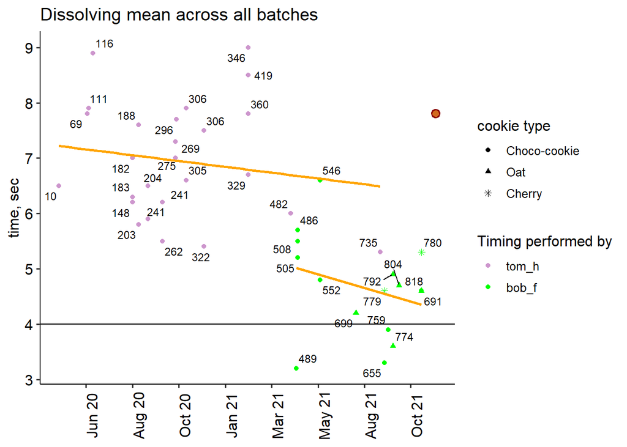

#### Different bakers

Now lets look closer into the difference between the cookies made by Tom and Bob.

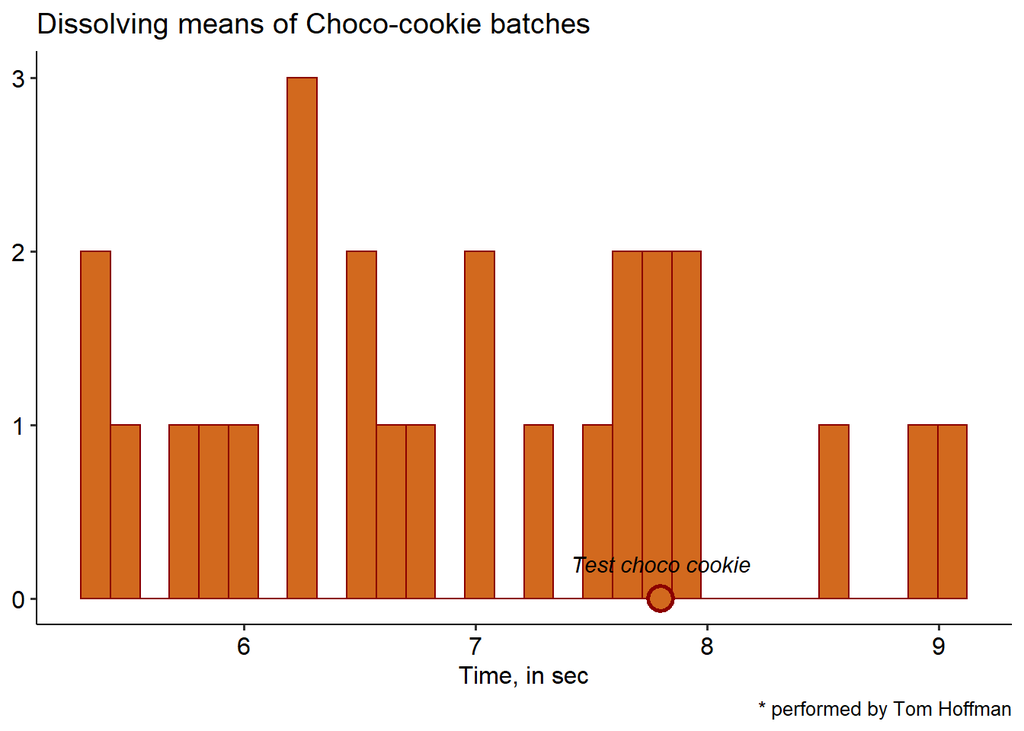

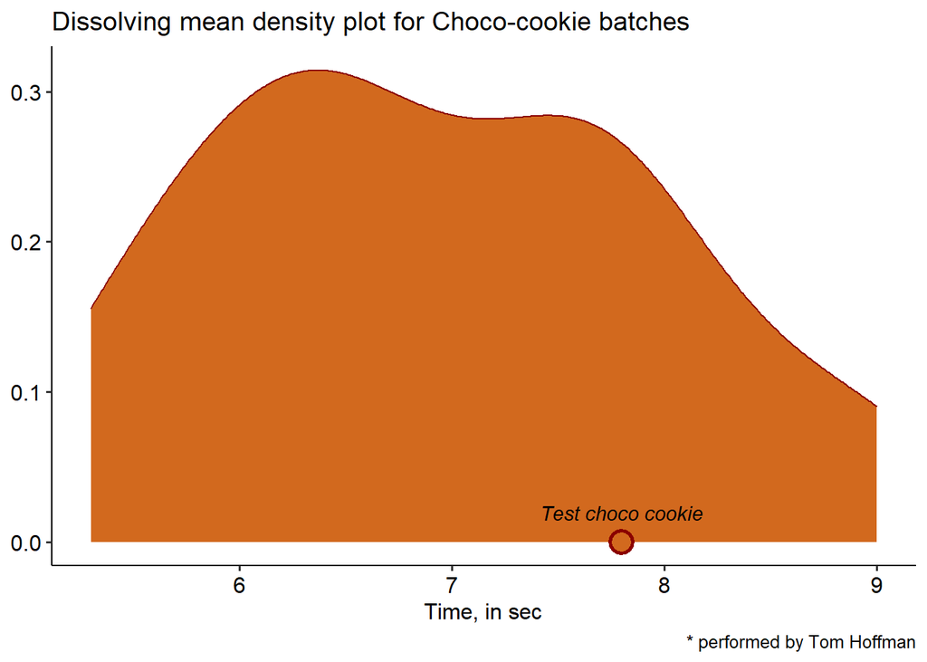

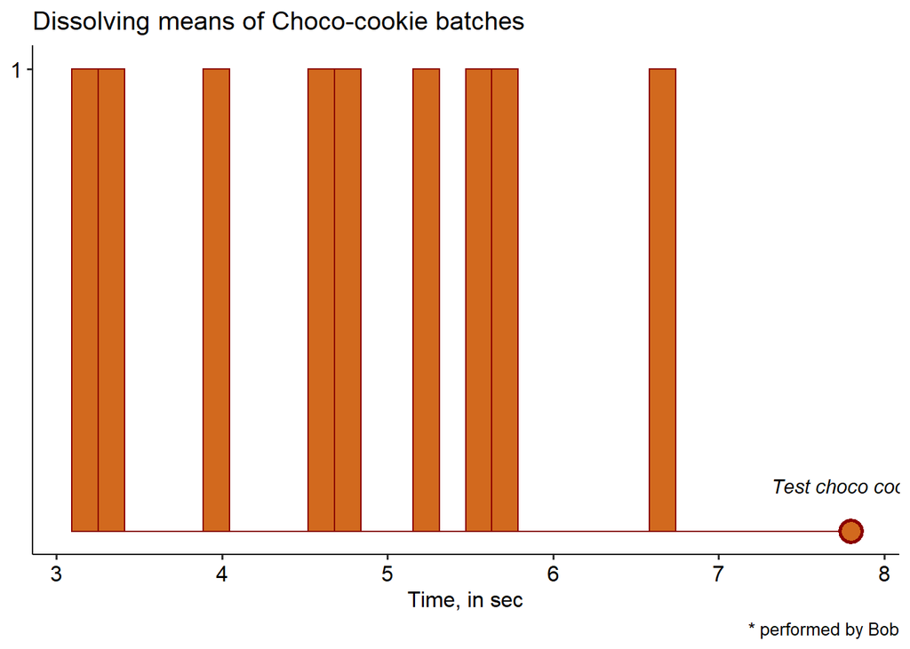

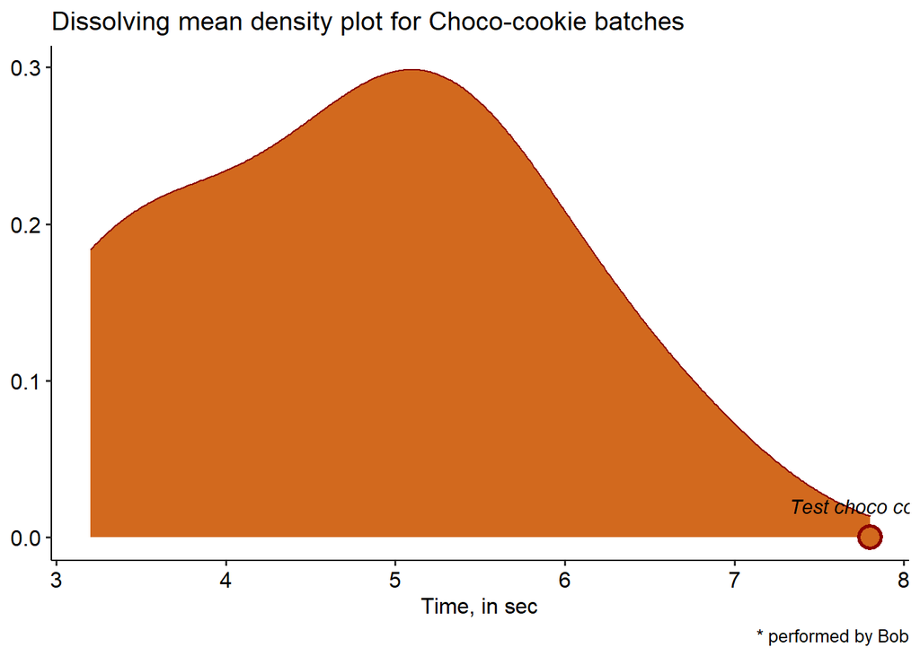

Thus, we reject our first null-hypothesis: *Cookie dissolving time in milk is not affected by whom the cookies are made.* Now we know that **there is a difference** between the bakers.

Our **conclusion** here would be: Bob needs to get a training from Tom on how to make cookies.

#### Temperature

We also wanted to know if dissolving time is affected by the local temperature.

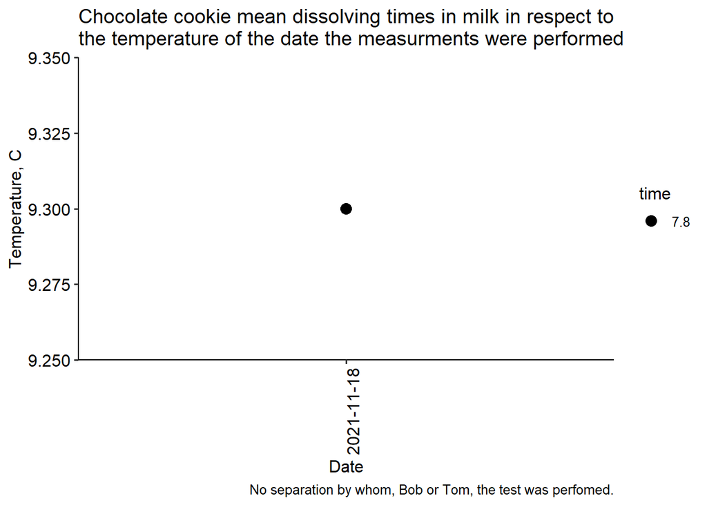

## General data overview

#### CVs of other time parameters

To make use of other data available we calculate and plot CV values. CV is a variation metric, that is calculated as *st.dev / mean* for a respective time parameter. A lower CV value represents a lower variation within the batch.

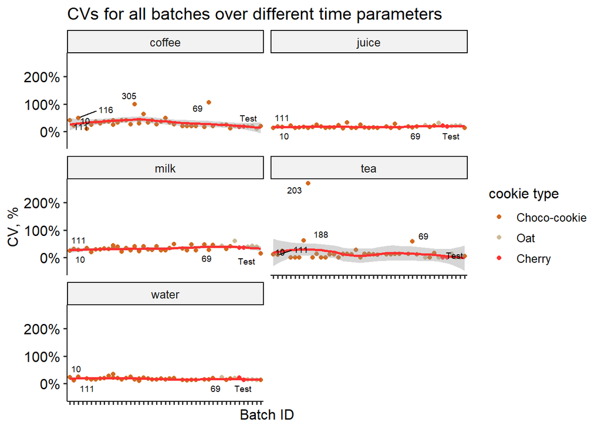